# RNA seq workflow part 4 - Volcano plot

HIOs dual seq experiment 2

Ryan Berger

2018-08-09

# 1 Purpose

This script is part of a workflow for RNA seq processing and analysis (modified from [Bioconductor](https://www.bioconductor.org/help/workflows/rnaseqGene/)). The purpose is to take in differential expression .csv files and create volcano plots showing global gene changes. For this analysis, we’ll make a single figure with the volcano plots from all the differential expression files over PBS control.

# 2 Begin script

## 2.1 Libraries and directories

```r
library(ggplot2)
library(here)
library(knitr)
library(rmarkdown)
library(stringi)
```

## 2.2 Load the data

Start by making a single volcano plot using `ggplot`. We’ll use the STM over PBS 2h file to make this.

```r
# Load data
stm2 <- read.csv(here('results/DESeq2_human/diff_expression/STM_2h_over_PBS_2h_diffexpress.csv'), header = T)

head(stm2)
```

```
##   baseMean log2FoldChange     lfcSE     stat        pvalue         padj
## 1 2182.718       6.615802 0.3073934 21.52226 9.634739e-103 1.466022e-98
## 2 3764.806       2.283908 0.1253305 18.22308  3.385398e-74 2.575611e-70
## 3 7894.619       6.194937 0.3427036 18.07666  4.866782e-73 1.851324e-69
## 4 4981.821       3.975904 0.2198257 18.08662  4.062486e-73 1.851324e-69
## 5 3788.687       5.652319 0.3139673 18.00289  1.849020e-72 5.626937e-69
## 6 2915.637       5.882106 0.3335966 17.63239  1.389546e-69 3.020476e-66
##   symbol entrez                                name
## 1  CXCL2   2920      C-X-C motif chemokine ligand 2
## 2 NFKBIZ  64332                 NFKB inhibitor zeta
## 3  CXCL1   2919      C-X-C motif chemokine ligand 1
## 4 NFKBIA   4792                NFKB inhibitor alpha
## 5  CXCL3   2921      C-X-C motif chemokine ligand 3
## 6  BIRC3    330 baculoviral IAP repeat containing 3
```

We’re also going to facet the plots by sample and time point. We’ll make a function to define categories for each of these in our data.

```r
# Function to prep data
prep_df <- function(df, label, time){
  # Set label for conditions
  df$label <- label
  df$time <- time

  # Set up labels for colors
  df$colors <- 'Non significant'
  df[which(df$log2FoldChange < 0 & df$padj < 0.05), 'colors'] <- 'Decreasing'
  df[which(df$log2FoldChange > 0 & df$padj < 0.05), 'colors'] <- 'Increasing'
  df$colors <- factor(df$colors, levels = c('Non significant', 'Decreasing', 'Increasing'))

  return(df)
}

stm2 <- prep_df(stm2, label = 'STM', time = '2h')
```

## 2.3 Build volcano plot

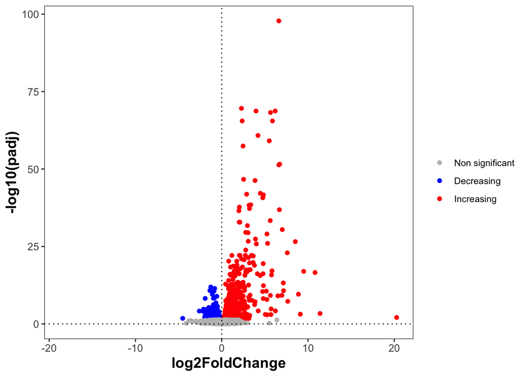

```r
ggplot(data = stm2, aes(x=log2FoldChange, y=-log10(padj),
                        color=colors, label=symbol))+
  geom_point()+
  geom_vline(xintercept = 0, linetype = 'dotted')+
  geom_hline(yintercept = 0, linetype = 'dotted')+
  scale_color_manual(name = '',
                     values = c('Non significant' = 'gray',
                                'Decreasing' = 'blue',
                                'Increasing' = 'red'))+
  theme_bw()+
  theme(panel.grid.major = element_line(linetype = "blank"),
    panel.grid.minor = element_line(linetype = "blank"),
    axis.title = element_text(size = 14,
        face = "bold"), axis.text = element_text(size = 10))
```

## 2.4 Build multi-panel volcano plot

This individual plot will serve as the template for our multipanel facet plot with all the samples and time points. To make it, we’ll load all the files and combine them into a single dataframe that we’ll facet into rows and columns in a plot.

```r
# Locate all the files
files <- list.files(here('results/DESeq2_human/diff_expression/'))
files
```

```
##  [1] "SE_2h_over_PBS_2h_diffexpress.csv"
##  [2] "SE_8h_over_PBS_8h_diffexpress.csv"
##  [3] "SPI1_2h_over_PBS_2h_diffexpress.csv"
##  [4] "SPI1_8h_over_PBS_8h_diffexpress.csv"
##  [5] "SPI2_2h_over_PBS_2h_diffexpress.csv"
##  [6] "SPI2_8h_over_PBS_8h_diffexpress.csv"
##  [7] "ST_2h_over_PBS_2h_diffexpress.csv"
##  [8] "ST_8h_over_PBS_8h_diffexpress.csv"
##  [9] "STM_2h_over_PBS_2h_diffexpress.csv"
## [10] "STM_8h_over_PBS_8h_diffexpress.csv"
```

```r
# Create an empty object to put the files into
data1 <- NULL

# Iterate over all files and combine into a single dataframe
for(i in seq(files)){
  file <- files[i]
  # Extract sample label and time point
  label <- gsub('_.*$',"",file)
  time <- stri_extract_first_regex(file, '[0-9]h')

  # Load file
  temp <- read.csv(here(paste0('results/DESeq2_human/diff_expression/',file)), header = T)

  temp <- prep_df(temp, label = label, time = time)

  data1 <- rbind(data1, temp)
  print(paste(i, 'of', length(files), 'done:', files[i]))
  }
```

```
## [1] "1 of 10 done: SE_2h_over_PBS_2h_diffexpress.csv"
## [1] "2 of 10 done: SE_8h_over_PBS_8h_diffexpress.csv"
## [1] "3 of 10 done: SPI1_2h_over_PBS_2h_diffexpress.csv"
## [1] "4 of 10 done: SPI1_8h_over_PBS_8h_diffexpress.csv"
## [1] "5 of 10 done: SPI2_2h_over_PBS_2h_diffexpress.csv"
## [1] "6 of 10 done: SPI2_8h_over_PBS_8h_diffexpress.csv"
## [1] "7 of 10 done: ST_2h_over_PBS_2h_diffexpress.csv"
## [1] "8 of 10 done: ST_8h_over_PBS_8h_diffexpress.csv"
## [1] "9 of 10 done: STM_2h_over_PBS_2h_diffexpress.csv"
## [1] "10 of 10 done: STM_8h_over_PBS_8h_diffexpress.csv"
```

```r
# Set order of samples for plot
data1$label <- factor(data1$label, levels = c('SE','ST','STM','SPI1','SPI2'))
```

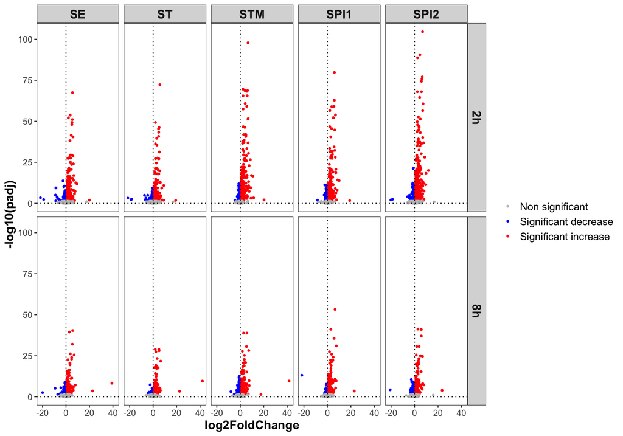

```r
# Make plot - facet time into rows, samples into columns

p <- ggplot(data = data1, aes(x=log2FoldChange, y=-log10(padj),
                              color=colors, label=symbol))+
  geom_point(size=.85)+
  geom_vline(xintercept = 0, linetype = 'dotted')+
  geom_hline(yintercept = 0, linetype = 'dotted')+
  scale_color_manual(name = '',
                     values = c('Non significant' = 'gray',
                                'Decreasing' = 'blue',
                                'Increasing' = 'red'),
                     labels = c('Non significant',
                                'Significant decrease',
                                'Significant increase'))+
  theme_bw()+
  theme(panel.grid.major = element_line(linetype = "blank"),
        panel.grid.minor = element_line(linetype = "blank"),
        axis.title = element_text(size = 14, face = "bold"),
        axis.text = element_text(size = 10),
        legend.text = element_text(size = 12),
        strip.text.x = element_text(size = 14, face = 'bold'),
        strip.text.y = element_text(size = 14, face = 'bold'))+
  facet_grid(rows = vars(time), cols = vars(label))

p
```

## 2.5 Thoughts about results

- More genes are increasing than decreasing in all samples.
- There are more gene changes at 2h than 8h in all samples.
- The pattern of gene changes is more similar by time point than by bacteria injected.
- There are a handful of genes that are extremely up and down-regulated (log2 fold change > 20)

## 2.6 Filter out lncRNA

When we look at the above plots, we can see that there are a few points that have extreme fold change levels ($2^{-20}, 2^{40}$) and after checking the data we found that these are long non coding RNAs. We then looked further into our dataset to see how many lncRNAs are present by using a regular expression (symbol starts with RP then a number, no ENTREZID) and found that there are approximately 4000 lncRNAs in each differential expression file. We aren’t really interested in these RNAs for our analysis and so we filtered them out of our dataset and re-made the volcano plots.

```r
# Identify long non coding RNAs
lncrna <- dplyr::filter(data1, grepl("^RP([0-9]).*",symbol) & is.na(entrez) == T)
head(lncrna)
```

```
##    baseMean log2FoldChange     lfcSE      stat       pvalue         padj
## 1  83.46343     -8.6005273 1.2163509 -7.070762 1.540856e-12 3.873271e-10
## 2  16.76016      3.5770629 0.5581182  6.409150 1.463334e-10 2.649302e-08
## 3  39.81686      1.5647452 0.3085420  5.071417 3.948646e-07 3.563096e-05
## 4  26.00482      2.2104393 0.4855409  4.552529 5.300480e-06 3.140312e-04
## 5  42.09917    -21.7869040 4.8606596 -4.482294 7.384502e-06 4.010422e-04
## 6 331.48503     -0.9005607 0.2104632 -4.278947 1.877799e-05 8.582272e-04
##          symbol entrez name label time     colors
## 1 RP11-270C12.3     NA <NA>    SE   2h Decreasing
## 2  RP1-145M24.1     NA <NA>    SE   2h Increasing
## 3  RP11-583F2.1     NA <NA>    SE   2h Increasing
## 4  RP11-986E7.7     NA <NA>    SE   2h Increasing
## 5   RP5-850E9.3     NA <NA>    SE   2h Decreasing
## 6   RP4-765C7.2     NA <NA>    SE   2h Decreasing
```

```r
# Select all rows in data1 that are not in lncrna
data2 <- dplyr::anti_join(data1, lncrna)
```

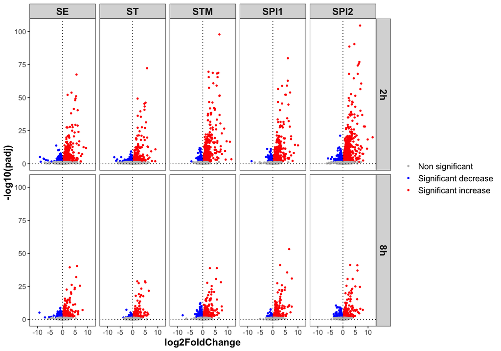

```r
# Make plot - facet time into rows, samples into columns

volcano_plot <- function(input){
ggplot(data = input, aes(x=log2FoldChange, y=-log10(padj),
                              color=colors, label=symbol))+
  geom_point(size=.85)+
  geom_vline(xintercept = 0, linetype = 'dotted')+
  geom_hline(yintercept = 0, linetype = 'dotted')+
  scale_color_manual(name = '',
                     values = c('Non significant' = 'gray',
                                'Decreasing' = 'blue',
                                'Increasing' = 'red'),
                     labels = c('Non significant',
                                'Significant decrease',
                                'Significant increase'))+
  theme_bw()+
  theme(panel.grid.major = element_line(linetype = "blank"),
        panel.grid.minor = element_line(linetype = "blank"),
        axis.title = element_text(size = 14, face = "bold"),
        axis.text = element_text(size = 10),
        legend.text = element_text(size = 12),
        strip.text.x = element_text(size = 14, face = 'bold'),
        strip.text.y = element_text(size = 14, face = 'bold'))+
  facet_grid(rows = vars(time), cols = vars(label))+
  xlim(-12,12)
}

p <- volcano_plot(data2)
p
```

## 2.7 Save png of plot

```r
png(filename = here("/img/volcano_facet.png"),
    width = 900, height = 600)
print(p)
dev.off()

# Save data
write.csv(data2, file = here('results/DESeq2_human/volcano_data.csv'))
```

# 3 Split samples

The paper will be split into sections and so we’ll split the plots into two groups of samples:

- STM mutants (STM, SPI-1, SPI-2)
- Serovars (STM, SE, ST)

## 3.1 STM mutants volcano plot

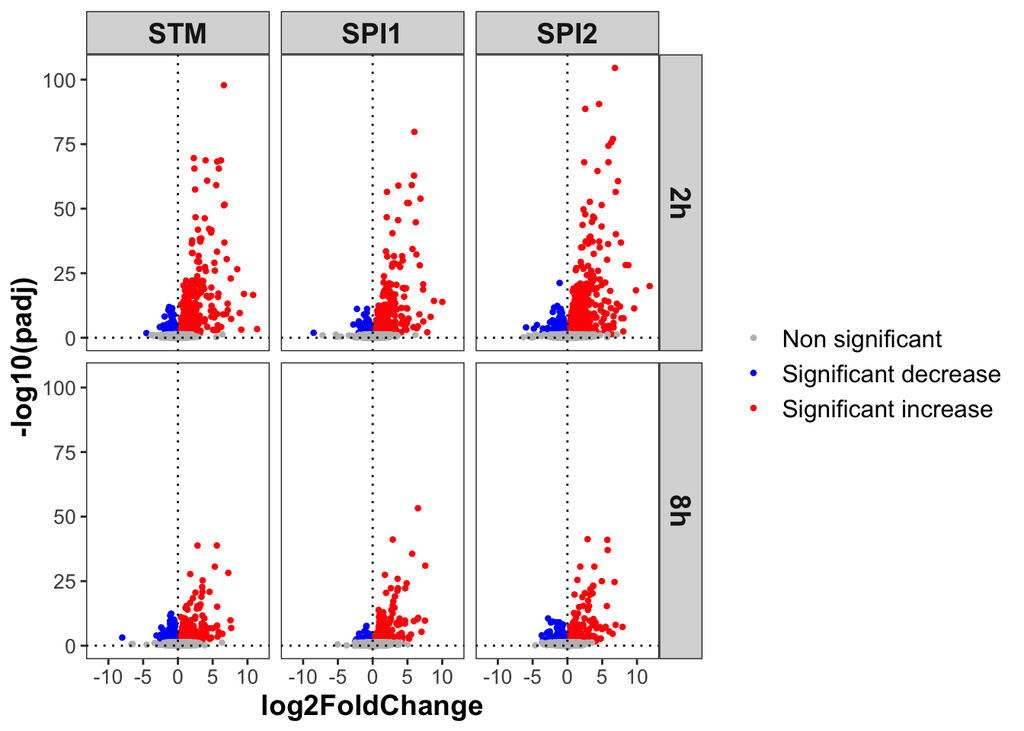

```r
mut <- dplyr::filter(data2, label %in% c('STM','SPI1','SPI2')) %>%
  volcano_plot()
mut
```

## 3.2 Serovars volcano plot

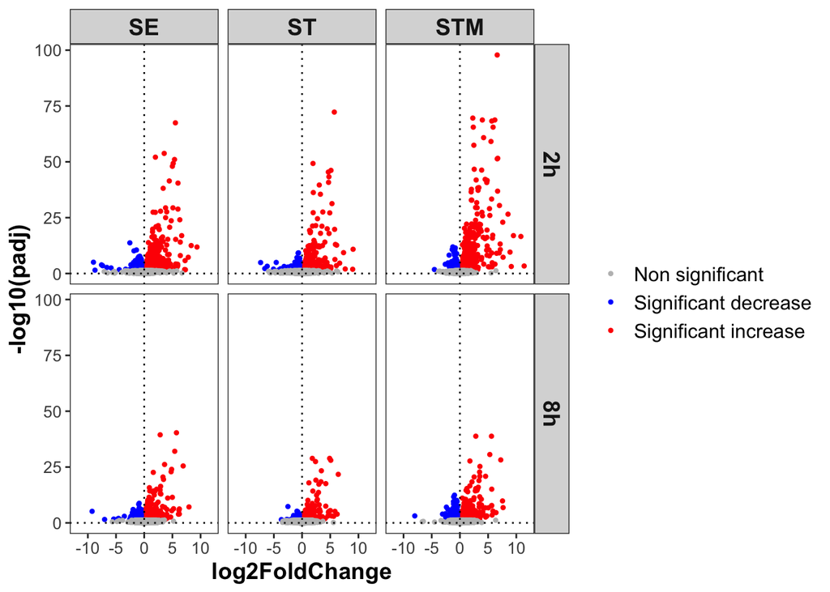

```r
ser <- dplyr::filter(data2, label %in% c('STM','SE','ST')) %>%
  volcano_plot()
ser
```

## 3.3 Save as png

```r
png(filename = here("/img/stm_mutants/mut_volcano_facet.png"),
    width = 9, height = 6, units = 'in', res = 300)
print(mut)
dev.off()


png(filename = here("/img/serovars/ser_volcano_facet.png"),
    width = 9, height = 6, units = 'in', res = 300)
print(ser)
dev.off()
```